# Titanic Data Analysis

This is titanic survival dataset which have information about the people who travelled in the titanic.This dataset contains information about 891 passengers having different parameters and with the information they survived or not. the dataset contains variuos columns which are as under

### Dataset Parameters:

- Survival : Survival (0 = Not Survived ,1 = Survived)
- Pclass : Passenger class (1 = Upper class ,2 = Middle class , 3 = Lower class)
- Name : Name of the passenger
- Sex : Male/Female
- Age : Age of the Passenger
- Sibsp : No of siblings /spouses aboard the Titanic

  ```
      1. sibling = brother,sister,stepbrother, stepsister
      2. spouses = husband ,wife
  ```

- Parch : No of parents and children aboard the Titanic

  ```
      1. Parent  = mother and father
      2. Child = daughter, son
      3. some children travelled alone or with nanny so they have parch = 0 for them
  ```

- Ticket : Ticket no of passenger
- Fare : Fare of the ticket
- Cabin : Contains the cabin number
- Embarked : Contains port of Embarkation. Contains three value.(C = Cherbourg, Q = Queenstown, S = Southampton)

### Questions To Explore:

- How many people survived and how many not? Did Gender played any important role?
- Did Passenger Class Played any role ?
- Did any particular age grouped people survived more?
- Did female and child of particular class got more priority?
- Travelling from some port for (2 = Middle class or 3 = lowe class) affect their survival rate?
- Did family relation played any role ? ( Whole family survived or something like no one from whole family survived)

### Loading Data:

To import the data from csv file python has inbuilt Pandas function which reads the information into dataframe

```python
import pandas as pd

titanic_data = pd.read_csv('titanic-data.csv')
titanic_data.head()
```

|  | PassengerId | Survived | Pclass | Name | Sex | Age | SibSp | Parch | Ticket | Fare | Cabin | Embarked |
| --- | --- | --- | --- | --- | --- | --- | --- | --- | --- | --- | --- | --- |
| 0 | 1 | 0 | 3 | Braund, Mr. Owen Harris | male | 22.0 | 1 | 0 | A/5 21171 | 7.2500 | NaN | S |
| 1 | 2 | 1 | 1 | Cumings, Mrs. John Bradley (Florence Briggs Th... | female | 38.0 | 1 | 0 | PC 17599 | 71.2833 | C85 | C |
| 2 | 3 | 1 | 3 | Heikkinen, Miss. Laina | female | 26.0 | 0 | 0 | STON/O2. 3101282 | 7.9250 | NaN | S |
| 3 | 4 | 1 | 1 | Futrelle, Mrs. Jacques Heath (Lily May Peel) | female | 35.0 | 1 | 0 | 113803 | 53.1000 | C123 | S |
| 4 | 5 | 0 | 3 | Allen, Mr. William Henry | male | 35.0 | 0 | 0 | 373450 | 8.0500 | NaN | S |

```python
titanic_data.describe()
```

|  | PassengerId | Survived | Pclass | Age | SibSp | Parch | Fare |
| --- | --- | --- | --- | --- | --- | --- | --- |
| count | 891.000000 | 891.000000 | 891.000000 | 714.000000 | 891.000000 | 891.000000 | 891.000000 |
| mean | 446.000000 | 0.383838 | 2.308642 | 29.699118 | 0.523008 | 0.381594 | 32.204208 |
| std | 257.353842 | 0.486592 | 0.836071 | 14.526497 | 1.102743 | 0.806057 | 49.693429 |
| min | 1.000000 | 0.000000 | 1.000000 | 0.420000 | 0.000000 | 0.000000 | 0.000000 |
| 25% | 223.500000 | 0.000000 | 2.000000 | 20.125000 | 0.000000 | 0.000000 | 7.910400 |
| 50% | 446.000000 | 0.000000 | 3.000000 | 28.000000 | 0.000000 | 0.000000 | 14.454200 |
| 75% | 668.500000 | 1.000000 | 3.000000 | 38.000000 | 1.000000 | 0.000000 | 31.000000 |
| max | 891.000000 | 1.000000 | 3.000000 | 80.000000 | 8.000000 | 6.000000 | 512.329200 |

```python
titanic_data.info()
```

```
<class 'pandas.core.frame.DataFrame'>
RangeIndex: 891 entries, 0 to 890
Data columns (total 12 columns):
PassengerId    891 non-null int64
Survived       891 non-null int64
Pclass         891 non-null int64
Name           891 non-null object
Sex            891 non-null object
Age            714 non-null float64
SibSp          891 non-null int64
Parch          891 non-null int64
Ticket         891 non-null object
Fare           891 non-null float64
Cabin          204 non-null object
Embarked       889 non-null object
dtypes: float64(2), int64(5), object(5)
memory usage: 83.6+ KB
```

### Data Cleaning

- As you can see from above information that cabin column has most of NaN values so it will not be useful to for exploration

```python
del titanic_data['Cabin']
titanic_data.head()
```

|  | PassengerId | Survived | Pclass | Name | Sex | Age | SibSp | Parch | Ticket | Fare | Embarked |
| --- | --- | --- | --- | --- | --- | --- | --- | --- | --- | --- | --- |
| 0 | 1 | 0 | 3 | Braund, Mr. Owen Harris | male | 22.0 | 1 | 0 | A/5 21171 | 7.2500 | S |
| 1 | 2 | 1 | 1 | Cumings, Mrs. John Bradley (Florence Briggs Th... | female | 38.0 | 1 | 0 | PC 17599 | 71.2833 | C |
| 2 | 3 | 1 | 3 | Heikkinen, Miss. Laina | female | 26.0 | 0 | 0 | STON/O2. 3101282 | 7.9250 | S |
| 3 | 4 | 1 | 1 | Futrelle, Mrs. Jacques Heath (Lily May Peel) | female | 35.0 | 1 | 0 | 113803 | 53.1000 | S |
| 4 | 5 | 0 | 3 | Allen, Mr. William Henry | male | 35.0 | 0 | 0 | 373450 | 8.0500 | S |

### Analyzing Survival Rate

```python
survival_data = titanic_data['Survived']
survived = (survival_data == 1).sum()
not_survived = (survival_data == 0).sum()
print ("Total No of people:",len(titanic_data['PassengerId']))
print ("No  of people survived:",survived)
print ("No of people Not Survived:",not_survived)
```

```
Total No of people: 891
No  of people survived: 342
No of people Not Survived: 549
```

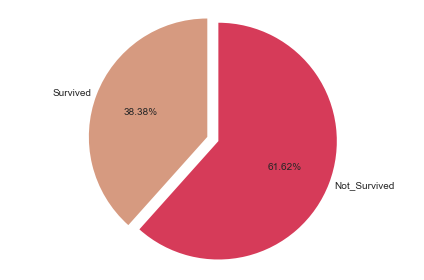

```python
%pylab inline
import matplotlib.pyplot as plt
# Create a list of colors
colors = ["#D69A80", "#D63B59"]

def draw_pi_chart(labels,sizes):

    plt.pie(sizes,labels=labels,colors =colors,autopct='%1.2f%%',startangle=90,shadow=False,explode=(0,0.10),labeldistance=1.05)
    # View the plot drop above
    plt.axis('equal')
    # View the plot
    plt.tight_layout()
    plt.show()

draw_pi_chart(['Survived', 'Not_Survived'],[survived,not_survived])
```

- Above pie chart shows the overall survival rate.From the chart we can see that there are 62 % of people who are not able to survived and 38% people are abled to survive.

Now we want to analyze this data by Gender,Age,and passenger class

```
                                       1.Analyzing Survival Rate by Gender
```

```
_____________________________________________
Total No of Males: 577
Total No of Male Survived: 109
Total No of Male Not Survived: 468
_____________________________________________
Total No of Females: 314
Total No of Female Survived: 233
Total No of Female Not Survived: 81
_____________________________________________
```

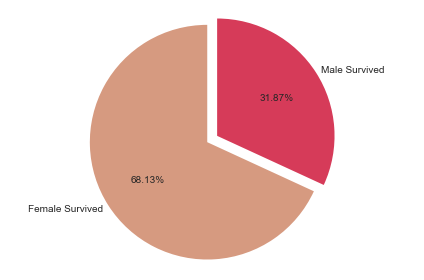

```python
gender_data = titanic_data['Sex']
male_count = (gender_data == "male").sum()
female_count = (gender_data =="female").sum()

male_survived = ((gender_data =="male") & (survival_data == 1)).sum()
male_not_survived = male_count - male_survived

female_survived = ((gender_data =="female") & (survival_data == 1 )).sum()
female_not_survived = female_count -female_survived

print ("_____________________________________________")

print ("Total No of Males:",male_count)
print ("Total No of Male Survived:",male_survived)
print ("Total No of Male Not Survived:",male_not_survived)

print ("_____________________________________________")

print ("Total No of Females:",female_count)
print ("Total No of Female Survived:",female_survived)
print ("Total No of Female Not Survived:",female_not_survived)

print ("_____________________________________________")

draw_pi_chart(["Female Survived","Male Survived"],[female_survived,male_survived])
```

```
                                    2. Analyzing Survival Rate by Passenger class
```

```python
pclass = titanic_data['Pclass']
# to retrive pclass data
pclass_values = sorted(pclass.unique())
#sorted() to sort the series
#unique() because we want only unique 3 number for the loop not the list:
def calculate_Survival_Rate(condition=True):
    print('----------------------------------')
    for val in pclass_values:
        pclass_count = ((pclass == val) & (condition)).sum()
        pclass_survivors = ((pclass == val)&(survival_data == 1) & (condition)).sum()
        pclass_casualties = ((pclass == val)&(survival_data == 0) & (condition)).sum()

        print('Pclass {0} Metrics: '.format(val))
        print('Total Count : ',pclass_count)
        print('Total Number Of Survivors: ',pclass_survivors)
        print('Total Number Of casualties: ',pclass_casualties)
        print ("pclass_survivors:",pclass_survivors)
        print('Survival Rate: {0}%'.format(round((np.divide(pclass_survivors,pclass_count)*100.0),2)))
        print('----------------------------------')
calculate_Survival_Rate()
```

```
----------------------------------
Pclass 1 Metrics:
Total Count :  216
Total Number Of Survivors:  136
Total Number Of casualties:  80
pclass_survivors: 136
Survival Rate: 62.96%
----------------------------------
Pclass 2 Metrics:
Total Count :  184
Total Number Of Survivors:  87
Total Number Of casualties:  97
pclass_survivors: 87
Survival Rate: 47.28%
----------------------------------
Pclass 3 Metrics:
Total Count :  491
Total Number Of Survivors:  119
Total Number Of casualties:  372
pclass_survivors: 119
Survival Rate: 24.24%
----------------------------------
```

- From above analysis it is clearly visible that the passengers who are from first and second class got higher priority compared to the third passenger class people.
- From the analysis we are able to see that there are more no of people who were travelling in 3rd pclass. It is also shown that the survival rate of passenger class 3 is only 24.24 % which is very low.
- As we already know that womens were given higher priority then males ,we want to explore how the thing vary with each class female srvival and male survival

```
                               3.Analyzing Survival Rate By Gender And Passenger Class
```

```python
calculate_Survival_Rate(gender_data == 'female')
```

```
----------------------------------
Pclass 1 Metrics:
Total Count :  94
Total Number Of Survivors:  91
Total Number Of casualties:  3
pclass_survivors: 91
Survival Rate: 96.81%
----------------------------------
Pclass 2 Metrics:
Total Count :  76
Total Number Of Survivors:  70
Total Number Of casualties:  6
pclass_survivors: 70
Survival Rate: 92.11%
----------------------------------
Pclass 3 Metrics:
Total Count :  144
Total Number Of Survivors:  72
Total Number Of casualties:  72
pclass_survivors: 72
Survival Rate: 50.0%
----------------------------------
```

```python
calculate_Survival_Rate(gender_data == "male")
```

```
----------------------------------
Pclass 1 Metrics:
Total Count :  122
Total Number Of Survivors:  45
Total Number Of casualties:  77
pclass_survivors: 45
Survival Rate: 36.89%
----------------------------------
Pclass 2 Metrics:
Total Count :  108
Total Number Of Survivors:  17
Total Number Of casualties:  91
pclass_survivors: 17
Survival Rate: 15.74%
----------------------------------
Pclass 3 Metrics:
Total Count :  347
Total Number Of Survivors:  47
Total Number Of casualties:  300
pclass_survivors: 47
Survival Rate: 13.54%
----------------------------------
```

1. **From Female Results:**
   - We can see that survival rate of female in first and second class is almost double compare to the third class.Results shows that almost all the females were survived who were in the fisrt passenger class.But in the case of the third passenger class female scenario only 50.0% were survived.
2. **From Male Results:** From the result two things can be noticed
   - There are more no of males in the pclass 3,it is almost half plus to the total males in the ship data.
   - Survival rate in all three class is very less compared to females.More no of male candidates were survived in class 1.But in case of class 2 and 3 the ratio is almost simillar.As there are more no of males in class 3 number of males who were not abled to survive is quit large compared to 2

```
                                        4.Analyzing Surival Rate By Age
```

```python
titanic_data[['PassengerId','Survived','Name','Sex','Age']].head()
age_data = titanic_data['Age']
# here we have droped missing values
age_data.dropna()
survived_age_data =age_data[survival_data == 1]
not_survived_age_data = age_data[survival_data == 0]
len(survived_age_data)
#342
len(not_survived_age_data)
#549
oldest_to_survive=survived_age_data.max()
youngest_to_survive =survived_age_data.min()

oldest_to_die = not_survived_age_data.max()
youngest_to_die = not_survived_age_data.min()


print('------------------------------')
print('Oldest To Survive: ',oldest_to_survive)
print('Youngest To Survive: ',youngest_to_survive)
print('------------------------------')
print('Oldest To die: ',oldest_to_die)
print('Youngest To die: ',youngest_to_die)
```

```
------------------------------
Oldest To Survive:  80.0
Youngest To Survive:  0.42
------------------------------
Oldest To die:  74.0
Youngest To die:  1.0
```

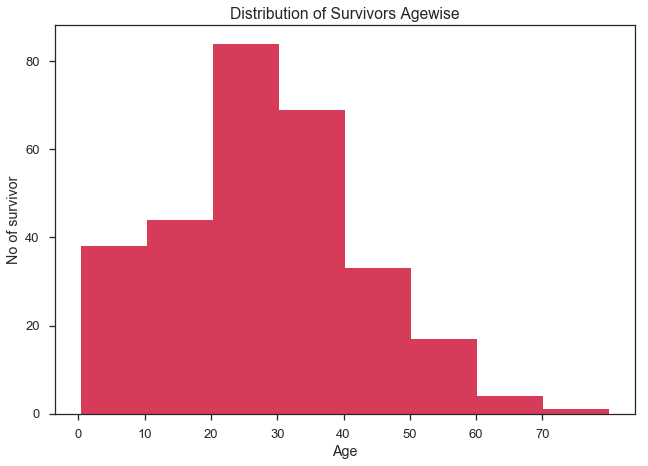

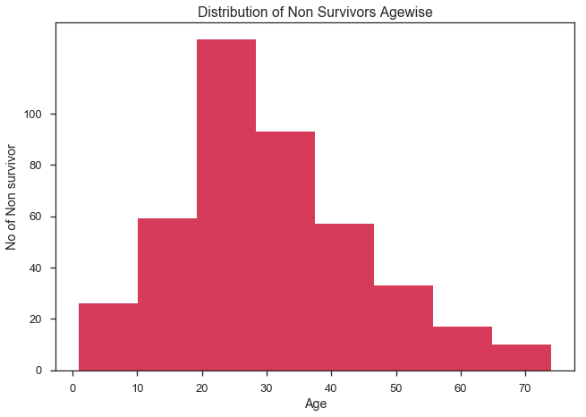

```python
import seaborn as sns
age_data = titanic_data['Age']
survived_age_data = age_data[survival_data==1].dropna()
not_survived_age_data = age_data[survival_data == 0].dropna()
def draw_histogram(data,title,xlabel,ylabel,xticks =None, yticks = None, bins =None, color=None):

    #sns.set_style("darkgrid", {"axes.facecolor": ".9"})
    sns.set_style("ticks")
    sns.set_context("talk")
    plt.title(title)
    plt.xlabel(xlabel)
    plt.ylabel(ylabel)

    if xticks != None:
        plt.xticks(xticks)

    if yticks != None:
        plt.yticks(yticks)

    plt.hist(data,bins=bins,color=color)
    plt.show()
draw_histogram(survived_age_data,'Distribution of Survivors Agewise','Age','No of survivor',xticks=range(0,80,10),yticks=range(0,120,20),bins=8,color = '#D63B59')
draw_histogram(not_survived_age_data,'Distribution of Non Survivors Agewise','Age','No of Non survivor',xticks=range(0,80,10),yticks=range(0,120,20),bins=8,color = '#D63B59')
```

```python
child_total=titanic_data[age_data <10]
print("No of children Below Age 10:",len(child_total))
print ("_________________________________________________________")

child_not_survived_data = titanic_data[(age_data < 10) & (survival_data == 0)]
print("No of children Below Age 10 and Not Survived:",len(child_not_survived_data))

child_survived_data = titanic_data[(age_data < 10) & (survival_data == 1)]
print("No of children Below Age 10 and Survived:",len(child_survived_data))

def find_ratio(survived,total):

    survival_ratio = round((survived/total)*100,2)

    return survival_ratio
child_survival_ratio = find_ratio(len(child_survived_data),len(child_total))
print("__________________________________________________________")
print("Child Survival Ratio:",child_survival_ratio)
```

```
No of children Below Age 10: 62
_________________________________________________________
No of children Below Age 10 and Not Survived: 24
No of children Below Age 10 and Survived: 38
__________________________________________________________
Child Survival Ratio: 61.29
```

```python
child_not_survived_data[['PassengerId','Survived','Name','Sex','Age','Ticket','Parch','Pclass']].head(10)
```

|  | PassengerId | Survived | Name | Sex | Age | Ticket | Parch | Pclass |
| --- | --- | --- | --- | --- | --- | --- | --- | --- |
| 7 | 8 | 0 | Palsson, Master. Gosta Leonard | male | 2.0 | 349909 | 1 | 3 |
| 16 | 17 | 0 | Rice, Master. Eugene | male | 2.0 | 382652 | 1 | 3 |
| 24 | 25 | 0 | Palsson, Miss. Torborg Danira | female | 8.0 | 349909 | 1 | 3 |
| 50 | 51 | 0 | Panula, Master. Juha Niilo | male | 7.0 | 3101295 | 1 | 3 |
| 63 | 64 | 0 | Skoog, Master. Harald | male | 4.0 | 347088 | 2 | 3 |
| 119 | 120 | 0 | Andersson, Miss. Ellis Anna Maria | female | 2.0 | 347082 | 2 | 3 |
| 147 | 148 | 0 | Ford, Miss. Robina Maggie "Ruby" | female | 9.0 | W./C. 6608 | 2 | 3 |
| 164 | 165 | 0 | Panula, Master. Eino Viljami | male | 1.0 | 3101295 | 1 | 3 |
| 171 | 172 | 0 | Rice, Master. Arthur | male | 4.0 | 382652 | 1 | 3 |
| 182 | 183 | 0 | Asplund, Master. Clarence Gustaf Hugo | male | 9.0 | 347077 | 2 | 3 |

- Now we want to find out the detailed analysis of child who were not abled to survive and who were abled to survive.will do that by analyzing their family detail with the help of the ticket number.
  1. First we will check that whole family is not abled to survive or only child is not abled to survive.
  2. Second we will check that only child survived or whole family of the that child abled to survive.

```python
ticket_data =titanic_data['Ticket']
len(ticket_data)
ticket_no_of_not_survived = (ticket_data == '349909')|(ticket_data == '382652')|(ticket_data == '349909')|(ticket_data == '3101295')|(ticket_data == '347088')|(ticket_data == '347082')|(ticket_data == 'W./C. 6608')|(ticket_data == '382652')|(ticket_data == '347077')

titanic_data[(age_data > 10) &(ticket_no_of_not_survived)][['PassengerId','Survived','Name','Sex','Age','Ticket','Parch']].head(20)
```

|  | PassengerId | Survived | Name | Sex | Age | Ticket | Parch |
| --- | --- | --- | --- | --- | --- | --- | --- |
| 13 | 14 | 0 | Andersson, Mr. Anders Johan | male | 39.0 | 347082 | 5 |
| 25 | 26 | 1 | Asplund, Mrs. Carl Oscar (Selma Augusta Emilia... | female | 38.0 | 347077 | 5 |
| 86 | 87 | 0 | Ford, Mr. William Neal | male | 16.0 | W./C. 6608 | 3 |
| 167 | 168 | 0 | Skoog, Mrs. William (Anna Bernhardina Karlsson) | female | 45.0 | 347088 | 4 |
| 266 | 267 | 0 | Panula, Mr. Ernesti Arvid | male | 16.0 | 3101295 | 1 |
| 360 | 361 | 0 | Skoog, Mr. Wilhelm | male | 40.0 | 347088 | 4 |
| 436 | 437 | 0 | Ford, Miss. Doolina Margaret "Daisy" | female | 21.0 | W./C. 6608 | 2 |
| 542 | 543 | 0 | Andersson, Miss. Sigrid Elisabeth | female | 11.0 | 347082 | 2 |
| 567 | 568 | 0 | Palsson, Mrs. Nils (Alma Cornelia Berglund) | female | 29.0 | 349909 | 4 |
| 610 | 611 | 0 | Andersson, Mrs. Anders Johan (Alfrida Konstant... | female | 39.0 | 347082 | 5 |
| 638 | 639 | 0 | Panula, Mrs. Juha (Maria Emilia Ojala) | female | 41.0 | 3101295 | 5 |
| 686 | 687 | 0 | Panula, Mr. Jaako Arnold | male | 14.0 | 3101295 | 1 |
| 736 | 737 | 0 | Ford, Mrs. Edward (Margaret Ann Watson) | female | 48.0 | W./C. 6608 | 3 |
| 885 | 886 | 0 | Rice, Mrs. William (Margaret Norton) | female | 39.0 | 382652 | 5 |

- From above table we can see that none of the family members were survived either it is male or female except one female Mrs Carl who was luckily survived.
- By this we can also identify that if child is not abled to survive than in most of the cases whole family want be abled to survive.

```python
child_survived_data[['PassengerId','Survived','Name','Sex','Age','Ticket','Parch','Pclass']].head(10)
```

|  | PassengerId | Survived | Name | Sex | Age | Ticket | Parch | Pclass |
| --- | --- | --- | --- | --- | --- | --- | --- | --- |
| 10 | 11 | 1 | Sandstrom, Miss. Marguerite Rut | female | 4.00 | PP 9549 | 1 | 3 |
| 43 | 44 | 1 | Laroche, Miss. Simonne Marie Anne Andree | female | 3.00 | SC/Paris 2123 | 2 | 2 |
| 58 | 59 | 1 | West, Miss. Constance Mirium | female | 5.00 | C.A. 34651 | 2 | 2 |
| 78 | 79 | 1 | Caldwell, Master. Alden Gates | male | 0.83 | 248738 | 2 | 2 |
| 165 | 166 | 1 | Goldsmith, Master. Frank John William "Frankie" | male | 9.00 | 363291 | 2 | 3 |
| 172 | 173 | 1 | Johnson, Miss. Eleanor Ileen | female | 1.00 | 347742 | 1 | 3 |
| 183 | 184 | 1 | Becker, Master. Richard F | male | 1.00 | 230136 | 1 | 2 |
| 184 | 185 | 1 | Kink-Heilmann, Miss. Luise Gretchen | female | 4.00 | 315153 | 2 | 3 |
| 193 | 194 | 1 | Navratil, Master. Michel M | male | 3.00 | 230080 | 1 | 2 |
| 233 | 234 | 1 | Asplund, Miss. Lillian Gertrud | female | 5.00 | 347077 | 2 | 3 |

```python
ticket_no_of_survived = (ticket_data == 'PP 9549')|(ticket_data == 'SC/Paris 2123')|(ticket_data == 'C.A. 34651')|(ticket_data == '248738')|(ticket_data == '363291')|(ticket_data =='347742')|(ticket_data == '315153')|(ticket_data == '347077') | (ticket_data =='230080')

data_survived_parents = titanic_data[(age_data > 10 ) & (ticket_no_of_survived)][['PassengerId','Survived','Name','Sex','Age','Ticket','Parch','Pclass']].head(15)
data_survived_parents.style

#Now suppose you wanted to highlight the maximum value in each column.
#We can’t use .applymap anymore since that operated elementwise.
#Instead, we’ll turn to .apply which operates columnwise (or rowwise using the axis keyword).
#Styler.apply(func, axis=1) for rowwise styles

def highlight_man(s):
    '''
    To Highlight male rows in data
    '''
    #for condition to match 0
    is_max = s == 0
    if is_max['Survived'] :
        #print(is_max)
        is_max = is_max | True
        #if we write is_max = is_max ,it will only highlight survival column value
        #but we want to highlight whole row so will use | True
    return ['background-color: #ff9999' if v else '' for v in is_max]

data_survived_parents.style.apply(highlight_man,axis=1)
# axis = 1 for the rowwise
```

|  | PassengerId | Survived | Name | Sex | Age | Ticket | Parch | Pclass |
| --- | --- | --- | --- | --- | --- | --- | --- | --- |
| 8 | 9 | 1 | Johnson, Mrs. Oscar W (Elisabeth Vilhelmina Berg) | female | 27 | 347742 | 2 | 3 |
| 25 | 26 | 1 | Asplund, Mrs. Carl Oscar (Selma Augusta Emilia Johansson) | female | 38 | 347077 | 5 | 3 |
| 148 | 149 | 0 | Navratil, Mr. Michel ("Louis M Hoffman") | male | 36.5 | 230080 | 2 | 2 |
| 323 | 324 | 1 | Caldwell, Mrs. Albert Francis (Sylvia Mae Harbaugh) | female | 22 | 248738 | 1 | 2 |
| 328 | 329 | 1 | Goldsmith, Mrs. Frank John (Emily Alice Brown) | female | 31 | 363291 | 1 | 3 |
| 394 | 395 | 1 | Sandstrom, Mrs. Hjalmar (Agnes Charlotta Bengtsson) | female | 24 | PP 9549 | 2 | 3 |
| 450 | 451 | 0 | West, Mr. Edwy Arthur | male | 36 | C.A. 34651 | 2 | 2 |
| 472 | 473 | 1 | West, Mrs. Edwy Arthur (Ada Mary Worth) | female | 33 | C.A. 34651 | 2 | 2 |
| 548 | 549 | 0 | Goldsmith, Mr. Frank John | male | 33 | 363291 | 1 | 3 |
| 608 | 609 | 1 | Laroche, Mrs. Joseph (Juliette Marie Louise Lafargue) | female | 22 | SC/Paris 2123 | 2 | 2 |
| 685 | 686 | 0 | Laroche, Mr. Joseph Philippe Lemercier | male | 25 | SC/Paris 2123 | 2 | 2 |

- From upper table which we retrieved from survived child data we can see that female family members with the child also abled to survive but most of male member were not abled to survive.The hghlighted red row highlights the male family members who were not abled to survive.
- By this we can also conclude that female and children were given higher priority.

```
                            5.Explore survival and not survival with the port of embarkation
```

```python
port_data=titanic_data['Embarked']
port_data.describe()
port_values=port_data.unique()
# here we are deleting the NaN value from the list priori we haven't deleted that but we are removing here.
#we can also remove by using dropna() as we did in age
port_values = port_values[:-1]
def calculate_Survival_By_Port(condition=True):
    print('----------------------------------')
    for val in port_values:
        port_count = ((port_data == val) & (condition)).sum()
        port_survivors = ((port_data == val)&(survival_data == 1) & (condition)).sum()
        port_casualties = ((port_data == val)&(survival_data == 0) & (condition)).sum()

        print('Port {0} Metrics: '.format(val))
        print('Total Count : ',port_count)
        print('Total Number Of Survivors: ',port_survivors)
        print('Total Number Of casualties: ',port_casualties)
        print ("port_survivors:",port_survivors)
        print('Survival Rate: {0}%'.format(round((np.divide(port_survivors,port_count)*100.0),2)))
        print('----------------------------------')
calculate_Survival_By_Port()
```

```
----------------------------------
Port S Metrics:
Total Count :  644
Total Number Of Survivors:  217
Total Number Of casualties:  427
port_survivors: 217
Survival Rate: 33.7%
----------------------------------
Port C Metrics:
Total Count :  168
Total Number Of Survivors:  93
Total Number Of casualties:  75
port_survivors: 93
Survival Rate: 55.36%
----------------------------------
Port Q Metrics:
Total Count :  77
Total Number Of Survivors:  30
Total Number Of casualties:  47
port_survivors: 30
Survival Rate: 38.96%
----------------------------------
```

- from the numbers we can see that most no of people were embaked from port S and very few from the Port C and Port Q.
- It is also noticed that the survival rate from port c is the higher compare to other port.

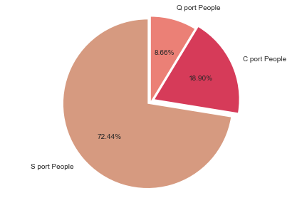

```python
sport= (port_data == 'S').sum()
cport= (port_data == 'C').sum()
qport= (port_data == 'Q').sum()
%pylab inline
import matplotlib.pyplot as plt

# Create a list of colors
colors = ["#D69A80", "#D63B59","#EB8076"]

def draw_pi_chart(labels,sizes):
    plt.pie(sizes,labels=labels,colors =colors,autopct='%1.2f%%',startangle=90,shadow=False,explode=(0.05,0.05,0),labeldistance=1.15)
    # View the plot drop above
    plt.axis('equal')
    # View the plot
    plt.tight_layout()
    plt.show()

draw_pi_chart(['S port People','C port People','Q port People'],[sport, cport, qport])
```

- Pie chart shows the graphical representation of % of people embarked from respective port

```
                       6. Further Exploring the survival rate by Gender & port of Embarkation.
```

```python
calculate_Survival_By_Port(gender_data == "male")
```

```
----------------------------------
Port S Metrics:
Total Count :  441
Total Number Of Survivors:  77
Total Number Of casualties:  364
port_survivors: 77
Survival Rate: 17.46%
----------------------------------
Port C Metrics:
Total Count :  95
Total Number Of Survivors:  29
Total Number Of casualties:  66
port_survivors: 29
Survival Rate: 30.53%
----------------------------------
Port Q Metrics:
Total Count :  41
Total Number Of Survivors:  3
Total Number Of casualties:  38
port_survivors: 3
Survival Rate: 7.32%
----------------------------------
```

- From above numbers we can see that survival rate for port Q is very low compared to other.
- There are only 3 males from port Q who were abled to survive.
- May be that case that for certain embarked port people were given the different part of the ship to stay and survival from that part became very difficult,or it may be the case that they were in part of ship which got highly damaged and survival became impossible.
- We also want to check that is it the same scenario for female from that port ?

```python
calculate_Survival_By_Port(gender_data == "female")
```

```
----------------------------------
Port S Metrics:
Total Count :  203
Total Number Of Survivors:  140
Total Number Of casualties:  63
port_survivors: 140
Survival Rate: 68.97%
----------------------------------
Port C Metrics:
Total Count :  73
Total Number Of Survivors:  64
Total Number Of casualties:  9
port_survivors: 64
Survival Rate: 87.67%
----------------------------------
Port Q Metrics:
Total Count :  36
Total Number Of Survivors:  27
Total Number Of casualties:  9
port_survivors: 27
Survival Rate: 75.0%
----------------------------------
```

### Few Interasting Findings

```python
explore_data = (titanic_data[(pclass == 2)&((gender_data == 'male')|(gender_data == 'female')) & (age_data < 10) ]
             [['PassengerId','Survived','Pclass','Name','Sex','Age','Parch']])

def highlight_age_lessThan10(s):
    '''
    highlight the age in a Series Red.
    '''
    is_max = [False,False,False,False,False,False,False]
    if s['Survived'] == 1:
        is_max[1]= True


    return ['background-color: #ff9999' if v else '' for v in is_max]

explore_data.style.apply(highlight_age_lessThan10,axis=1)
```

|  | PassengerId | Survived | Pclass | Name | Sex | Age | Parch |
| --- | --- | --- | --- | --- | --- | --- | --- |
| 43 | 44 | 1 | 2 | Laroche, Miss. Simonne Marie Anne Andree | female | 3 | 2 |
| 58 | 59 | 1 | 2 | West, Miss. Constance Mirium | female | 5 | 2 |
| 78 | 79 | 1 | 2 | Caldwell, Master. Alden Gates | male | 0.83 | 2 |
| 183 | 184 | 1 | 2 | Becker, Master. Richard F | male | 1 | 1 |
| 193 | 194 | 1 | 2 | Navratil, Master. Michel M | male | 3 | 1 |
| 237 | 238 | 1 | 2 | Collyer, Miss. Marjorie "Lottie" | female | 8 | 2 |
| 340 | 341 | 1 | 2 | Navratil, Master. Edmond Roger | male | 2 | 1 |
| 407 | 408 | 1 | 2 | Richards, Master. William Rowe | male | 3 | 1 |
| 530 | 531 | 1 | 2 | Quick, Miss. Phyllis May | female | 2 | 1 |
| 535 | 536 | 1 | 2 | Hart, Miss. Eva Miriam | female | 7 | 2 |
| 549 | 550 | 1 | 2 | Davies, Master. John Morgan Jr | male | 8 | 1 |
| 618 | 619 | 1 | 2 | Becker, Miss. Marion Louise | female | 4 | 1 |
| 720 | 721 | 1 | 2 | Harper, Miss. Annie Jessie "Nina" | female | 6 | 1 |
| 750 | 751 | 1 | 2 | Wells, Miss. Joan | female | 4 | 1 |
| 755 | 756 | 1 | 2 | Hamalainen, Master. Viljo | male | 0.67 | 1 |
| 827 | 828 | 1 | 2 | Mallet, Master. Andre | male | 1 | 2 |
| 831 | 832 | 1 | 2 | Richards, Master. George Sibley | male | 0.83 | 1 |

- From above table you can see that all male or female passenger who is below 10 years and from Pclass 2 survived.

```python
explore_data_1 = child_not_survived_data[['PassengerId','Survived','Pclass','Name','Sex','Age','Parch']]
# Here child_not_survived_data contains data of those child who were below 10 year age and were not abled to survive
def highlight_class(s):
    '''
    highlight the class in a Series Red.
    '''
    is_max = s == 3
    # because if we dont give age to false it will also highlight the pclass who is having age = 3
    is_max['Age'] = False
    return ['background-color: #ff9999' if v else '' for v in is_max]

explore_data_1.style.apply(highlight_class,axis=1)

# Another way of writing the same highlight function!

def highlight_class(s):
    '''
    highlight the class in a Series Red.
    '''
    is_max = [False,False,False,False,False,False,False]
    if s['Pclass'] == 3:
        is_max[2] = True

    return ['background-color: #ff9999' if v else '' for v in is_max]

explore_data_1.style.apply(highlight_class,axis=1)
```

|  | PassengerId | Survived | Pclass | Name | Sex | Age | Parch |
| --- | --- | --- | --- | --- | --- | --- | --- |
| 7 | 8 | 0 | 3 | Palsson, Master. Gosta Leonard | male | 2 | 1 |
| 16 | 17 | 0 | 3 | Rice, Master. Eugene | male | 2 | 1 |
| 24 | 25 | 0 | 3 | Palsson, Miss. Torborg Danira | female | 8 | 1 |
| 50 | 51 | 0 | 3 | Panula, Master. Juha Niilo | male | 7 | 1 |
| 63 | 64 | 0 | 3 | Skoog, Master. Harald | male | 4 | 2 |
| 119 | 120 | 0 | 3 | Andersson, Miss. Ellis Anna Maria | female | 2 | 2 |
| 147 | 148 | 0 | 3 | Ford, Miss. Robina Maggie "Ruby" | female | 9 | 2 |
| 164 | 165 | 0 | 3 | Panula, Master. Eino Viljami | male | 1 | 1 |
| 171 | 172 | 0 | 3 | Rice, Master. Arthur | male | 4 | 1 |
| 182 | 183 | 0 | 3 | Asplund, Master. Clarence Gustaf Hugo | male | 9 | 2 |
| 205 | 206 | 0 | 3 | Strom, Miss. Telma Matilda | female | 2 | 1 |
| 278 | 279 | 0 | 3 | Rice, Master. Eric | male | 7 | 1 |
| 297 | 298 | 0 | 1 | Allison, Miss. Helen Loraine | female | 2 | 2 |
| 374 | 375 | 0 | 3 | Palsson, Miss. Stina Viola | female | 3 | 1 |
| 386 | 387 | 0 | 3 | Goodwin, Master. Sidney Leonard | male | 1 | 2 |
| 480 | 481 | 0 | 3 | Goodwin, Master. Harold Victor | male | 9 | 2 |
| 541 | 542 | 0 | 3 | Andersson, Miss. Ingeborg Constanzia | female | 9 | 2 |
| 634 | 635 | 0 | 3 | Skoog, Miss. Mabel | female | 9 | 2 |
| 642 | 643 | 0 | 3 | Skoog, Miss. Margit Elizabeth | female | 2 | 2 |
| 787 | 788 | 0 | 3 | Rice, Master. George Hugh | male | 8 | 1 |
| 813 | 814 | 0 | 3 | Andersson, Miss. Ebba Iris Alfrida | female | 6 | 2 |
| 824 | 825 | 0 | 3 | Panula, Master. Urho Abraham | male | 2 | 1 |
| 850 | 851 | 0 | 3 | Andersson, Master. Sigvard Harald Elias | male | 4 | 2 |
| 852 | 853 | 0 | 3 | Boulos, Miss. Nourelain | female | 9 | 1 |

```python
explore_data_2 = titanic_data[(age_data > 60)][['PassengerId','Survived','Pclass','Name','Sex','Age','Parch',]]

def highlight_age(s):
    '''
    highlighting Non Survivals
    '''
    s['Age'] = math.floor(s['Age'])
    is_max = s == 0
    is_max[6] = False
#    is_max[5] = True &
 #   is_max['Sex'] == 'Females'
    return ['background-color: #ff9999' if v else '' for v in is_max]

explore_data_2.style.apply(highlight_age,axis=1)
```

|  | PassengerId | Survived | Pclass | Name | Sex | Age | Parch |
| --- | --- | --- | --- | --- | --- | --- | --- |
| 33 | 34 | 0 | 2 | Wheadon, Mr. Edward H | male | 66 | 0 |
| 54 | 55 | 0 | 1 | Ostby, Mr. Engelhart Cornelius | male | 65 | 1 |
| 96 | 97 | 0 | 1 | Goldschmidt, Mr. George B | male | 71 | 0 |
| 116 | 117 | 0 | 3 | Connors, Mr. Patrick | male | 70.5 | 0 |
| 170 | 171 | 0 | 1 | Van der hoef, Mr. Wyckoff | male | 61 | 0 |
| 252 | 253 | 0 | 1 | Stead, Mr. William Thomas | male | 62 | 0 |
| 275 | 276 | 1 | 1 | Andrews, Miss. Kornelia Theodosia | female | 63 | 0 |
| 280 | 281 | 0 | 3 | Duane, Mr. Frank | male | 65 | 0 |
| 326 | 327 | 0 | 3 | Nysveen, Mr. Johan Hansen | male | 61 | 0 |
| 438 | 439 | 0 | 1 | Fortune, Mr. Mark | male | 64 | 4 |
| 456 | 457 | 0 | 1 | Millet, Mr. Francis Davis | male | 65 | 0 |
| 483 | 484 | 1 | 3 | Turkula, Mrs. (Hedwig) | female | 63 | 0 |
| 493 | 494 | 0 | 1 | Artagaveytia, Mr. Ramon | male | 71 | 0 |
| 545 | 546 | 0 | 1 | Nicholson, Mr. Arthur Ernest | male | 64 | 0 |
| 555 | 556 | 0 | 1 | Wright, Mr. George | male | 62 | 0 |
| 570 | 571 | 1 | 2 | Harris, Mr. George | male | 62 | 0 |
| 625 | 626 | 0 | 1 | Sutton, Mr. Frederick | male | 61 | 0 |
| 630 | 631 | 1 | 1 | Barkworth, Mr. Algernon Henry Wilson | male | 80 | 0 |
| 672 | 673 | 0 | 2 | Mitchell, Mr. Henry Michael | male | 70 | 0 |
| 745 | 746 | 0 | 1 | Crosby, Capt. Edward Gifford | male | 70 | 1 |
| 829 | 830 | 1 | 1 | Stone, Mrs. George Nelson (Martha Evelyn) | female | 62 | 0 |
| 851 | 852 | 0 | 3 | Svensson, Mr. Johan | male | 74 | 0 |

```python
index = titanic_data['Fare'].idxmax()
ticket_max = titanic_data.iloc[index]['Ticket']
titanic_data[titanic_data['Ticket'] == ticket_max]
```

|  | PassengerId | Survived | Pclass | Name | Sex | Age | SibSp | Parch | Ticket | Fare | Embarked |
| --- | --- | --- | --- | --- | --- | --- | --- | --- | --- | --- | --- |
| 258 | 259 | 1 | 1 | Ward, Miss. Anna | female | 35.0 | 0 | 0 | PC 17755 | 512.3292 | C |
| 679 | 680 | 1 | 1 | Cardeza, Mr. Thomas Drake Martinez | male | 36.0 | 0 | 1 | PC 17755 | 512.3292 | C |
| 737 | 738 | 1 | 1 | Lesurer, Mr. Gustave J | male | 35.0 | 0 | 0 | PC 17755 | 512.3292 | C |

- From above table it is found that the people who have paid highest ticket fare were able to survive.

```python
sibiling_data =titanic_data['SibSp']
require_data = titanic_data[(sibiling_data > 3)][['Pclass','Name','Age','Survived','Parch','Ticket']]
def highlight_survival(s):
    is_max = [False,False,False,False,False,False]
    if s['Survived'] == 0:
        is_max[3] = True

    return ['background-color: #ff9999' if v else '' for v in is_max]

require_data.style.apply(highlight_survival,axis=1)
```

|  | Pclass | Name | Age | Survived | Parch | Ticket |
| --- | --- | --- | --- | --- | --- | --- |
| 16 | 3 | Rice, Master. Eugene | 2 | 0 | 1 | 382652 |
| 50 | 3 | Panula, Master. Juha Niilo | 7 | 0 | 1 | 3101295 |
| 59 | 3 | Goodwin, Master. William Frederick | 11 | 0 | 2 | CA 2144 |
| 68 | 3 | Andersson, Miss. Erna Alexandra | 17 | 1 | 2 | 3101281 |
| 71 | 3 | Goodwin, Miss. Lillian Amy | 16 | 0 | 2 | CA 2144 |
| 119 | 3 | Andersson, Miss. Ellis Anna Maria | 2 | 0 | 2 | 347082 |
| 159 | 3 | Sage, Master. Thomas Henry | nan | 0 | 2 | CA. 2343 |
| 164 | 3 | Panula, Master. Eino Viljami | 1 | 0 | 1 | 3101295 |
| 171 | 3 | Rice, Master. Arthur | 4 | 0 | 1 | 382652 |
| 180 | 3 | Sage, Miss. Constance Gladys | nan | 0 | 2 | CA. 2343 |
| 182 | 3 | Asplund, Master. Clarence Gustaf Hugo | 9 | 0 | 2 | 347077 |
| 201 | 3 | Sage, Mr. Frederick | nan | 0 | 2 | CA. 2343 |
| 233 | 3 | Asplund, Miss. Lillian Gertrud | 5 | 1 | 2 | 347077 |
| 261 | 3 | Asplund, Master. Edvin Rojj Felix | 3 | 1 | 2 | 347077 |
| 266 | 3 | Panula, Mr. Ernesti Arvid | 16 | 0 | 1 | 3101295 |
| 278 | 3 | Rice, Master. Eric | 7 | 0 | 1 | 382652 |
| 324 | 3 | Sage, Mr. George John Jr | nan | 0 | 2 | CA. 2343 |
| 386 | 3 | Goodwin, Master. Sidney Leonard | 1 | 0 | 2 | CA 2144 |
| 480 | 3 | Goodwin, Master. Harold Victor | 9 | 0 | 2 | CA 2144 |
| 541 | 3 | Andersson, Miss. Ingeborg Constanzia | 9 | 0 | 2 | 347082 |
| 542 | 3 | Andersson, Miss. Sigrid Elisabeth | 11 | 0 | 2 | 347082 |
| 683 | 3 | Goodwin, Mr. Charles Edward | 14 | 0 | 2 | CA 2144 |
| 686 | 3 | Panula, Mr. Jaako Arnold | 14 | 0 | 1 | 3101295 |
| 787 | 3 | Rice, Master. George Hugh | 8 | 0 | 1 | 382652 |
| 792 | 3 | Sage, Miss. Stella Anna | nan | 0 | 2 | CA. 2343 |
| 813 | 3 | Andersson, Miss. Ebba Iris Alfrida | 6 | 0 | 2 | 347082 |
| 824 | 3 | Panula, Master. Urho Abraham | 2 | 0 | 1 | 3101295 |
| 846 | 3 | Sage, Mr. Douglas Bullen | nan | 0 | 2 | CA. 2343 |
| 850 | 3 | Andersson, Master. Sigvard Harald Elias | 4 | 0 | 2 | 347082 |
| 863 | 3 | Sage, Miss. Dorothy Edith "Dolly" | nan | 0 | 2 | CA. 2343 |